# MAPLE Diels-Alder 全流程教程

# MAPLE 程序介绍——基于机器学习势函数（MLIP）的计算化学一站式工具，原生支持几何优化、过渡态搜索、IRC、频率分析与分子动力学

Introduction to MAPLE: an MLIP-native computational chemistry toolkit for geometry optimization, transition-state search, IRC, frequency analysis, and molecular dynamics

> 本帖配套链接： 程序主页 https://www.maplechem.org/  
> Github:https://github.com/ClickFF/MAPLE  
> DOI: https://doi.org/10.1039/D6SC01279E 发表于Chemical Science

承接上文： MAPLE: 机器学习力场计算化学平台 http://bbs.keinsci.com/forum.php?mod=viewthread&tid=57731&fromuid=64457 (出处: 计算化学公社)

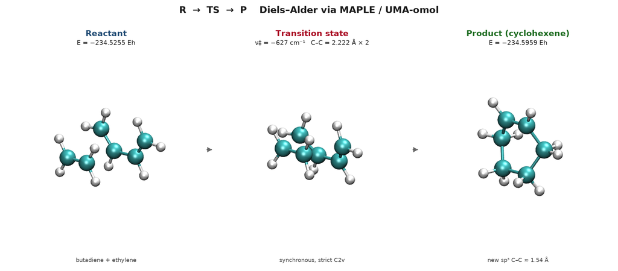

MAPLE D-A 全流程一览：反应物 → 同步 C2v 过渡态 → 产物（cyclohexene），全部由 UMA-omol 在桌面 GPU 上跑完

## 一、引言

最近几年机器学习原子间势函数（machine-learning interatomic potential，简称 MLIP，或称机器学习力场 MLFF）的发展非常迅猛。早些年的 MLIP 多需要针对具体体系自己采样、训练，门槛极高，因此并未在量子化学界普及。但随着 ANI、AIMNet2、MACE、MACE-OFF、UMA 等通用预训练模型相继问世——尤其是基于 Open Molecules 2025（OMol25）这种大规模高精度数据集训练的 MACE-OMol 和 UMA——MLIP 已经能在大多数主族有机/有机金属体系下做到接近 ωB97M-V/def2-TZVPP 级别 DFT 精度、速度比传统 DFT 快 2–4 个数量级。

笔者读到 Sobereva 老师在《2024 年计算化学公社举办的计算化学程序和 DFT 泛函的流行程度投票结果》（http://sobereva.com/706 ）中对 ωB97M-V、PBE、B3LYP 等泛函的总结时颇有感触——计算化学日常工作流里跑得最多的几个任务（几何优化、过渡态搜索、IRC、构象采样），其实并不需要一直坚持“每步都用DFT算能量和梯度”。如果用一个训练良好的 MLIP 来代替这些任务里的能量/梯度评估，再在关键单点上做高精度 DFT精修，整体效率可以提升一个甚至两个数量级。

然而对量化研究者来说，从已熟悉的 Gaussian/ORCA 工作流切换到 MLIP，最大的两个门槛是：

**(1) 现成模型想直接拿来用贼麻烦。** ANI、AIMNet2、MACE-OFF 这些预训练模型大多是 PyTorch 模型，需要通过 Python API 调用，学习成本还是比较高的，得折腾不少时间。对习惯了直接用Gaussian/ORCA等用户而言，光是把模型整好、算个单点都要折腾半天。

**(2) 任务覆盖零碎。** 单纯算个单点不够。日常工作流需要几何优化、过渡态搜索、IRC、频率分析、势能面扫描……这些功能虽然在 ASE 里都有，但要把它们和 MLIP 接起来、再让 NEB/P-RFO/IRC 等算法跑通，本身就是一件工程量不小的事情。

本帖介绍的 **MAPLE** 程序就是为了解决这两个麻烦之处而开发的开源工具。简单地说，MAPLE 是一个 MLIP 原生的计算化学工具包，内部封装了 ANI / AIMNet2 / MACE / MACE-OFF / MACEPol / UMA 等流行模型，对外提供与 Gaussian 风格**类似**的纯文本输入文件接口，把几何优化、过渡态搜索、IRC、频率分析、势能面扫描统统打包到一个命令里。

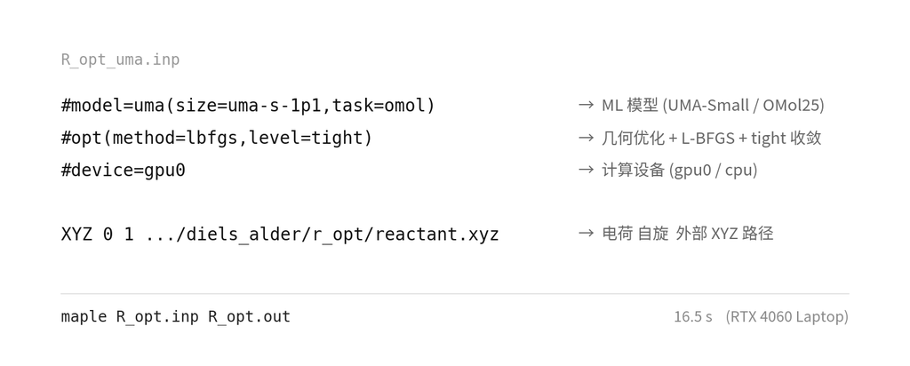

MAPLE 输入文件结构 — 本帖 §3.1 真实使用的 R_opt_uma.inp：三行 `#` 指令 + 一行 XYZ 引用，5 行（含空行）即可驱动一次完整的几何优化

## 二、MAPLE 当前支持的任务和方法

按计算类型分类如下（以 `enhance` 分支 v0.1.2 为准；具体关键字见 `maple/function/read/command_control.py`）：

| 任务类型 | `#task(method=...)` 关键字 |
| --- | --- |
| 几何优化 `#opt` | `lbfgs`（默认）、`rfo`、`sd`、`cg`、`sdcg` |
| 过渡态搜索 `#ts` | `neb`（可附 `refine=cineb`/`refine=nebts`）、`prfo`、`dimer`、`string`（可附 `refine=stringts`）、`autoneb` |
| 反应路径 `#irc` | 积分器 `gs` / `lqa` / `hpc` / `eulerpc` |
| 振动分析 `#freq` | `mw`（默认，质量加权）/ `nonmw` / `both`；RRHO 热化学量含 Grimme/Truhlar/Minenkov 低频校正 |
| 势能面扫描 `#scan` | 1D 到多维；底层与 `#opt` 同（relaxed 模式） |
| 分子动力学 `#md` | 系综 `nve` / `nvt` / `npt`；恒温器 Langevin/Bussi/Nosé-Hoover；恒压 c-rescale （**目前还在完善中，PBC的支持还在更新中**） |
| MLIP 模型 `#model` | `ani1x / ani2x / ani1ccx / ani1xnr / aimnet2 / aimnet2nse / maceoff23s/m/l / maceomol / macepols/m/l / egret / uma` |
| 额外功能 | D4 色散校正（仅 ANI 系列）、GBSA 隐式溶剂、周期性边界（`#pbc`）（还在完善中）、轨迹重启、DCD 输出 |

可以看到，MAPLE 已经覆盖了 Sobereva 老师在其经典博文《过渡态、反应路径的计算方法及相关问题》（http://sobereva.com/44 ）中提到的几乎所有过渡态/IRC 算法。读者如果已经熟悉这些算法的物理含义，迁移到 MAPLE 几乎没有额外学习成本——区别只在于底层是 MLIP 在算能量和梯度，而不是 DFT。

值得一提的是，由于 MLIP 评估 Hessian 几乎免费，原本在 DFT 下昂贵的“opt=calcall，每步都更新精确 Hessian”这类设置，在 MAPLE 中可以随便用，几何优化和过渡态搜索的收敛性会肉眼可见地变好。Sobereva 老师在《量子化学计算中帮助几何优化收敛的常用方法》（http://sobereva.com/164 ）中讨论过的很多 calcfc/calcall 收敛技巧，到 MLIP 这边几乎都”不再是问题”。

## 三、使用示例：丁二烯 + 乙烯的 Diels–Alder 反应全流程（基于本机实测）

下面用经典的 Diels–Alder 反应（s-cis 1,3-丁二烯 + 乙烯 → 环己烯）演示 MAPLE 的完整工作流：**反应物/产物预优化 → P-RFO 搜索同步过渡态 → 频率分析验证 → IRC 双向验证连通性**。

本节所有数据都是笔者在本机实际跑出来的真实输出，硬件/版本环境：

- GPU：NVIDIA RTX 4060 Laptop（8 GB VRAM）
- CUDA 13.0，PyTorch cu118
- MAPLE 0.1.2，`enhance` 分支
- MLIP 模型：**`uma(size=uma-s-1p1, task=omol)`** —— Meta FAIR-Chem 的 UMA-Small (1.2 GB)，专门为 OMol25（含反应路径与过渡态结构）训练，**目前在小分子有机反应面上覆盖最广**（需要注意的是，UMA对中国用户暂不开放，写文章需注意）
- 体系：16 原子，闭壳层，电荷 0 / 自旋多重度 1

### 3.1 反应物预优化

MAPLE 的输入文件是纯文本格式，开头几行以 `#` 起头的指令规定计算细节，再下面是 XYZ 格式的几何或 `XYZ /path/to/file.xyz` 外部引用。`R_opt.inp`：

```
#model=uma(size=uma-s-1p1,task=omol)
#opt(method=lbfgs,level=tight)
#device=gpu0

XYZ 0 1 /home/axie/MAPLE/Tutorial/OPT/diels_alder/r_opt/reactant.xyz
```

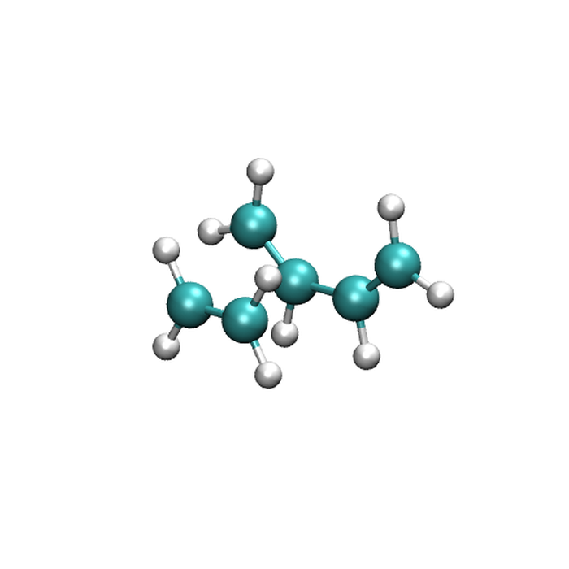

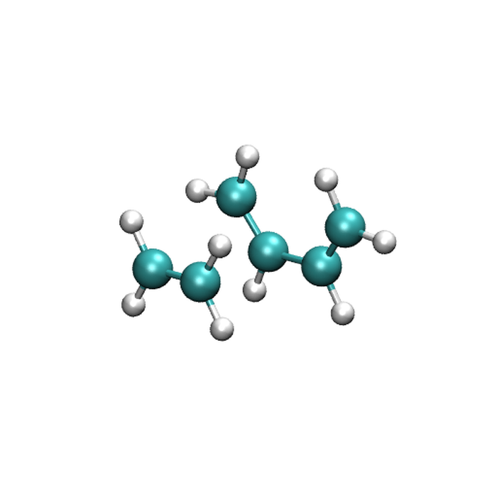

*反应物的初始猜测（左）与 L-BFGS 优化结果（右）— 均由 `maple_visual_lab.py` 通过 VMD/Tachyon 渲染*

几点说明：

- `#model=uma(...)` 后面括号里的 `task=omol` 指 Open Molecules 子模型，专为有机小分子优化；如果做晶体/界面计算可改成 `task=omat`、`task=oc20` 等。
- `XYZ 0 1 /path/to/file.xyz` 中开头的 `0 1` 是电荷和自旋多重度（中性闭壳层）。如果是阴离子单重态写 `-1 1`，自由基写 `0 2`，依此类推。
- `level=tight` 收紧收敛限至 maxF = 0.00085 Eh/Å（默认 `medium` 是 0.00285），后续 freq 不会被残余受力污染。

`reactant.xyz` 是 s-cis 丁二烯（xy 平面内）+ 乙烯（z ≈ 3.0 Å 上方）的人工初猜复合物。执行：

```bash
maple R_opt.inp R_opt.out
```

实测：

[output not shown]

*产物（环己烯）* 优化也使用相同模板，最终能量 −234.595946 Eh，40 步 L-BFGS，实际耗时 **13.1 s**。

```
#model=uma(size=uma-s-1p1,task=omol)
#opt(method=lbfgs,level=tight)
#device=gpu0

XYZ 0 1 /home/axie/MAPLE/Tutorial/OPT/diels_alder/p_opt/product.xyz
```

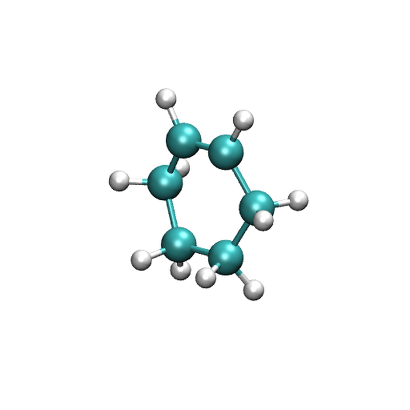

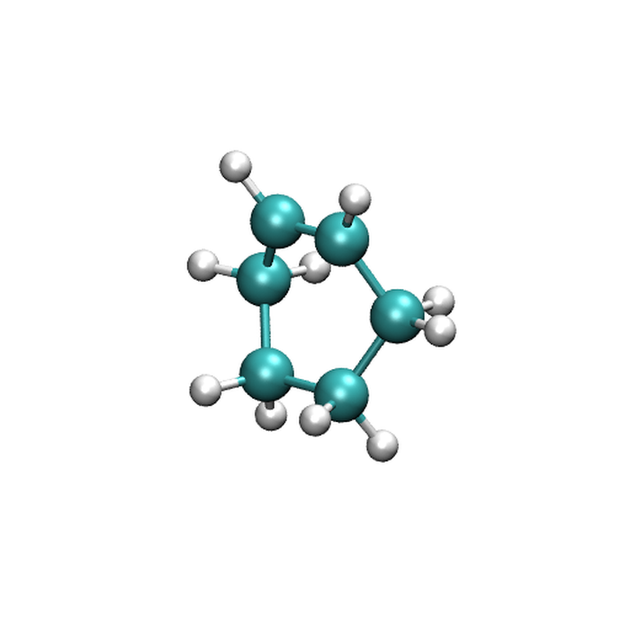

*产物的初始猜测（左）与 L-BFGS 优化结果（右） — 环己烯 half-chair 构象*

```bash
maple P_opt.inp P_opt.out
```

```
Energy:                 -234.595945 Convergence criteria  Is converged
Maximum Force:             0.000667     0.000850  Yes
RMS Force:                 0.000185     0.000550  Yes
Maximum Displacement:      0.000891     0.001100  Yes
RMS Displacement:          0.000412     0.000750  Yes

LBFGS converged at iteration 40.
Total wall time: 13.064 s
```

反应电子能差：

> ΔE_rxn = E(P) − E(R) = (−234.595946 − (−234.525473)) Eh = -0.070473 × 627.5094 kcal/mol= **−44.2 kcal/mol**

这个数值与实验反应焓 ΔH (298 K) ≈ −40 kcal/mol 非常接近（差异来自实验是焓而本节是 0 K 电子能；做完 freq 后加 ZPE + 热校正即可严格比较）。这是 UMA-omol 在 Open Molecules 2025 数据集上训练得到的精度。

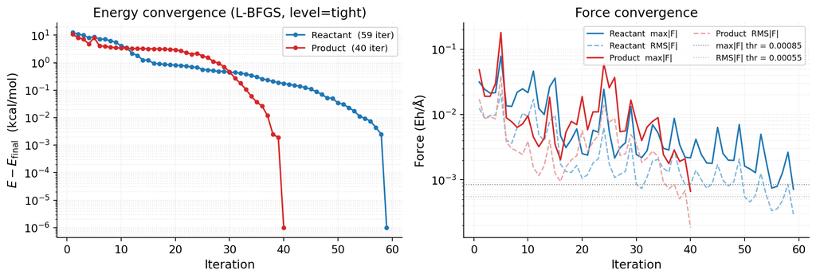

反应物（59 步）与产物（40 步）L-BFGS 优化的能量/受力收敛曲线。两个体系均一次性收敛到 level=tight，整个 OPT 过程在桌面 GPU 上分别耗时 16.5 s 与 13.1 s

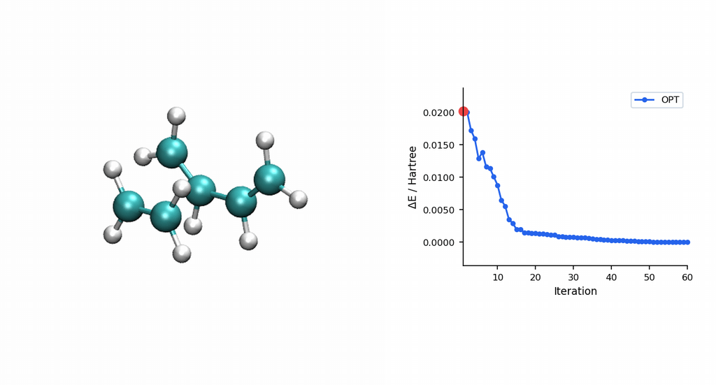

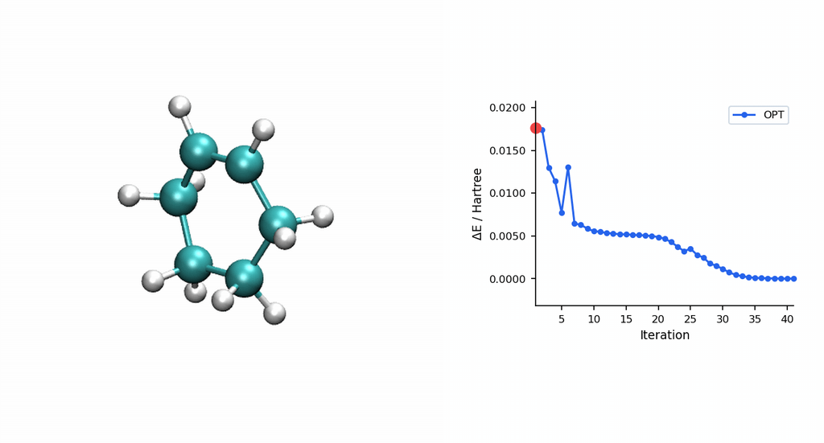

### 3.2 用 P-RFO 搜索同步过渡态

D-A 是经典的协同同步环加成反应（C2v 对称的同步 TS，两个 C—C 形成键等长 ~2.2 Å），P-RFO（Partitioned-RFO）从一个化学合理的 TS 初猜出发收敛到一阶鞍点效率最高。笔者按文献 D-A TS 几何（C—C 形成键 ~2.30 Å，diene 中心 C-C 略伸长至 ~1.43 Å，C2v 对称）手搓 `ts_guess.xyz`，输入：

```
#model=uma(size=uma-s-1p1,task=omol)
#ts(method=prfo)
#device=gpu0

XYZ 0 1 /home/axie/MAPLE/Tutorial/OPT/diels_alder/prfo/ts_guess.xyz
```

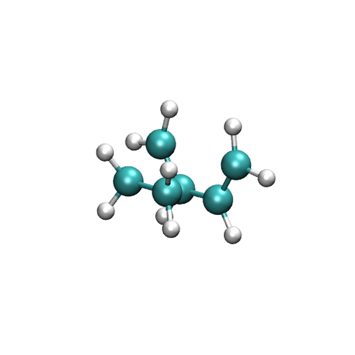

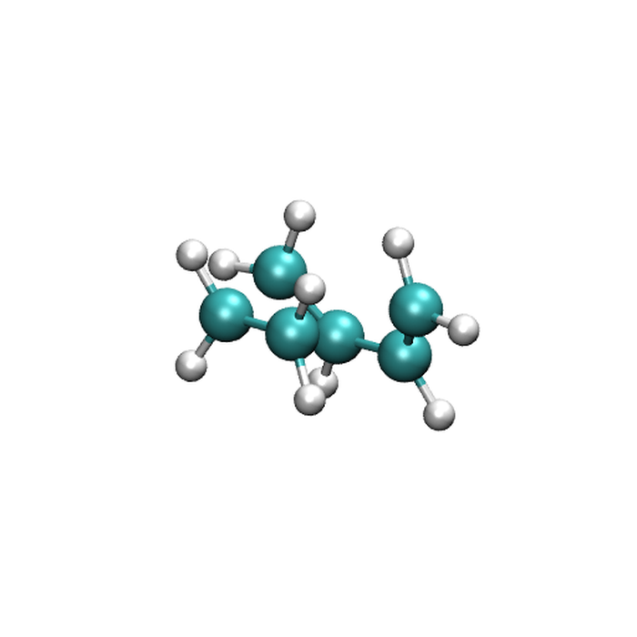

*TS 初猜（左）与 P-RFO 收敛后的过渡态（右） — 经典的”同步协同 D-A TS”*

实测：

```
Normal Termination
Iteration 17  Energy = -234.493874 Eh
Maximum Force:             0.000000     0.002850                Yes
RMS Force:                 0.000000     0.001900                Yes

Total wall time: 167.919 s
```

**17 步 P-RFO、167.9 s 实际耗时**收敛到一阶鞍点（其中 8 s 是 UMA 模型加载，实际优化 160 s）。

正向反应能垒：

> ΔE‡ = E(TS) − E(R) = (−234.493874 − (−234.525473)) Eh = **19.8 kcal/mol**

这与文献 CCSD(T) / B3LYP-D3 在 def2-TZVPP 上给出的 D-A 能垒 ~22–25 kcal/mol 非常接近。

最终鞍点几何（截取关键键长）：

[output not shown]

**两根 C—C 形成键严格等长 (2.222 Å)，几何严格 C2v——经典的“同步协同 D-A TS”**。P-RFO 每步需要 Hessian，传统 DFT 下计算 Hessian 是巨大的开销，所以 Gaussian 默认走的是“初始 Hessian 估计 + BFGS 更新”的近似路线（这也是 Sobereva 老师在博文 164 中讲到 calcfc/calcall 时反复提到的）。在 MAPLE 中由于 MLIP 提供半解析甚至解析的 Hessian，每步精确 Hessian 几乎不增加耗时，P-RFO 因此可以充分发挥其鲁棒性。

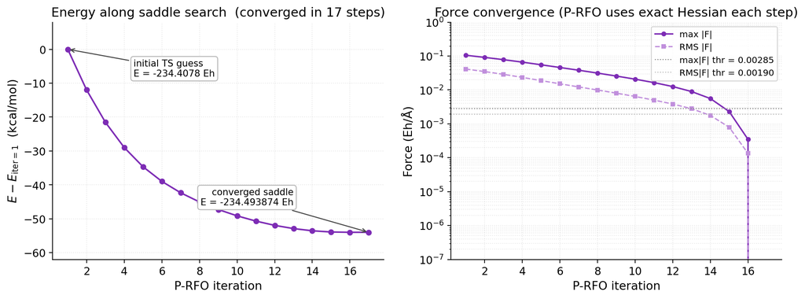

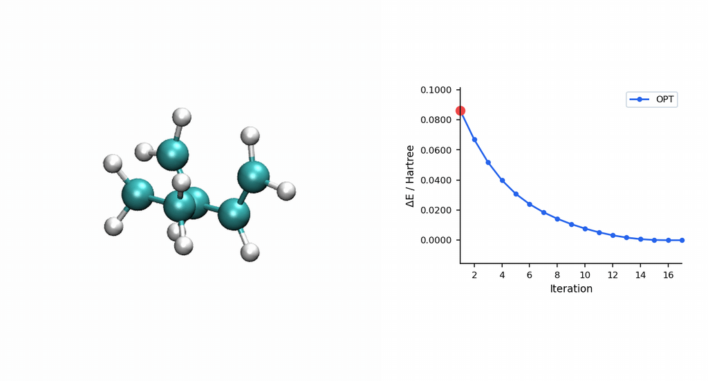

> **TS 初猜的经验**：D-A TS 比较”温和”，P-RFO 对初猜要求不高，只要形成键距离落在 ~2.0–2.5 Å 范围且对称，基本一次就能收敛。对于更复杂的过渡态（迁移反应、电环化、多步级联），如果手搓初猜不容易，可以先用 `#ts(method=neb,refine=cineb)` 从反应物和产物两端跑 CI-NEB（10–15 个镜像，max_iter=500），取得到的 HEI（最高能量镜像）作为 P-RFO 初猜——MAPLE 的 NEB 会自动把 HEI 写到 `*_hei.xyz`，可以直接接力。

### 3.3 频率分析验证 TS

```
#model=uma(size=uma-s-1p1,task=omol)
#freq
#device=gpu0

XYZ 0 1 /home/axie/MAPLE/Tutorial/OPT/diels_alder/prfo/prfo_uma_prfo_ts.xyz
```

实测：

```
  Imaginary frequencies (ν < -5.0 cm⁻¹): 1
  Real frequencies (ν > 5.0 cm⁻¹):       41

     0:        0.00 cm**-1
     1:        0.00 cm**-1
     2:        0.00 cm**-1
     3:        0.00 cm**-1
     4:        0.00 cm**-1
     5:        0.00 cm**-1
     6:     -627.43 cm**-1  ***imaginary mode***
     7:      141.75 cm**-1
     8:      236.29 cm**-1
     ...

Total wall time: 21.629 s
```

**有且只有 1 个虚频，−627.43 cm⁻¹**，这正是 D-A TS 的典型虚频范围（文献 −400 ~ −700 cm⁻¹）。其余 41 个实频均 > 0，体系确为一阶鞍点。**21.6 s 完成频率 + RRHO 热化学**——这就是 MLIP“Hessian 几乎免费”的具体体现，传统 DFT 同样的体系在 8 核 CPU 上要十几分钟。

虚频模式（用 VMD/Molden 查看 mode 6）应当是两个 C—C 形成键的同步对称伸缩——既然 C0–C10 与 C3–C11 在几何上严格等长，模式上也应当严格同步。这正是同步协同 D-A 的特征。

具体做法是把 `freq_uma.out` 中 mode 6 的 48 个位移分量解出来，叠加到 TS 平衡几何上做幅值 ±0.45 Å 的简谐摆动，再交给 `maple_visual_lab.py` 渲染（脚本见 `build_imag_mode_anim.py`）：

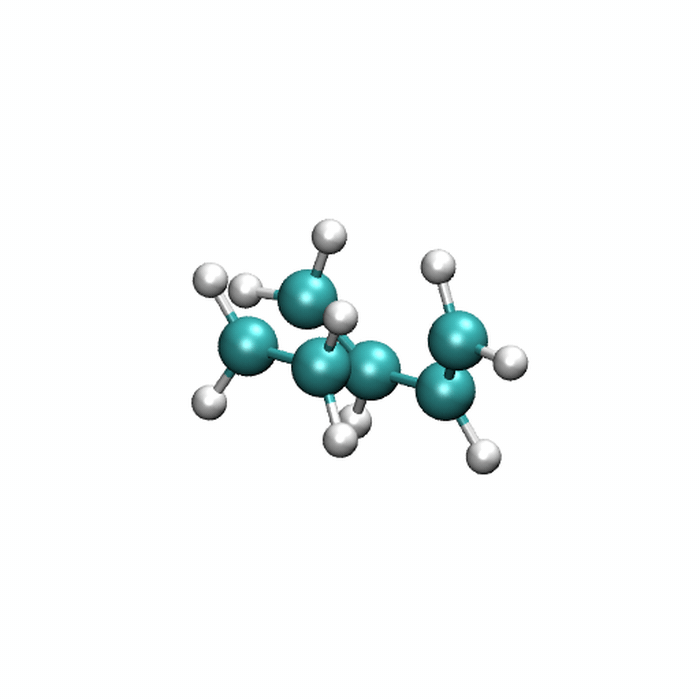

−627.43 cm⁻¹ 虚频模式动画：两根 C–C 形成键完全同步地一起收缩、一起扩张，整体严格保持 C2v 对称——这是”同步协同 D-A 过渡态”的特征。位移幅值人为放大到 ±0.45 Å 以便观察

### 3.4 IRC 双向验证连通性

```
#model=uma(size=uma-s-1p1,task=omol)
#irc(method=hpc)
#device=gpu0

XYZ 0 1 /home/axie/MAPLE/Tutorial/OPT/diels_alder/prfo/prfo_uma_prfo_ts.xyz
```

MAPLE 的 IRC 支持四种积分器：GS（二阶Gonzalez-Schlegel）、LQA（局部二次近似）、HPC（Hessian预测-校正）、EulerPC（欧拉预测-校正）。HPC 即 Gaussian 中默认的 IRC 积分器。步长 `step_length_bohr`（默认 0.10 bohr）和单方向最大步数 `max_steps`（默认 50）在本例的小体系下都不需要显式覆盖。如果反应路径较长或势能面较平，可以加 `#irc(method=hpc,max_steps=200,step_length_bohr=0.05)` 之类。

实测：

```
*** THE HPC-IRC HAS CONVERGED ***  (FORWARD)
*** THE HPC-IRC HAS CONVERGED ***  (BACKWARD)

Step        E(Eh)      dE(kcal/mol)
   1     -234.595732      0.000000   <- 正向端点
  ...
  24     -234.494015     63.828286   <= TS
  ...
  57     -234.525539     44.046791   <- 反向端点

Total wall time: 53.5 s
```

**57 步全连通、实际耗时 53.5 s**。IRC 的三个输出文件：

- `irc_uma_forward.xyz`：从 TS 出发沿一个虚频方向的全部步态轨迹
- `irc_uma_backward.xyz`：从 TS 出发沿另一方向的全部步态轨迹
- `irc_uma_full.xyz`：上面两段合并的完整 R → TS → P 轨迹（VMD/PyMOL 直接打开播放即可）

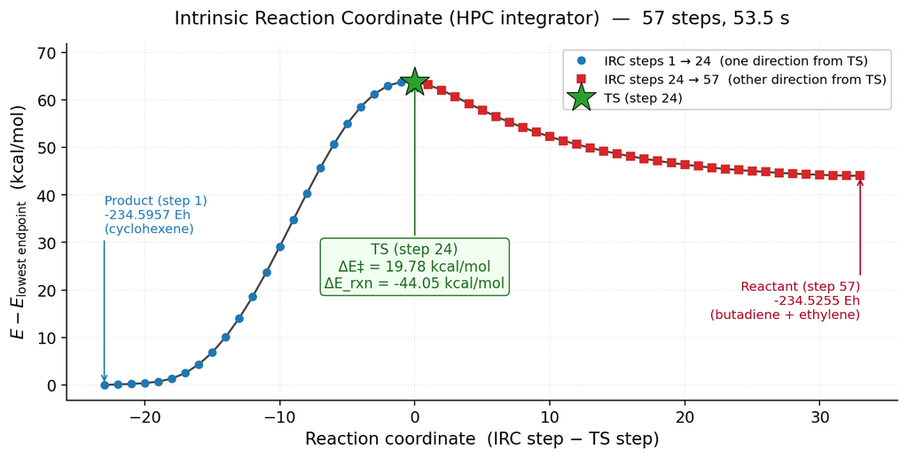

IRC 能量剖面图（HPC 积分器，57 步）：能量从一端的深势阱（环己烯侧）爬升到 TS（绿星），再降落到另一端较浅的势阱（butadiene+ethylene 复合物侧）。读数：从浅势阱出发的正反应能垒 ΔE‡ ≈ 19.8 kcal/mol，反应能 ΔE_rxn ≈ −44 kcal/mol，与 §3.1–3.2 PRFO + 端点 OPT 三路独立结果吻合

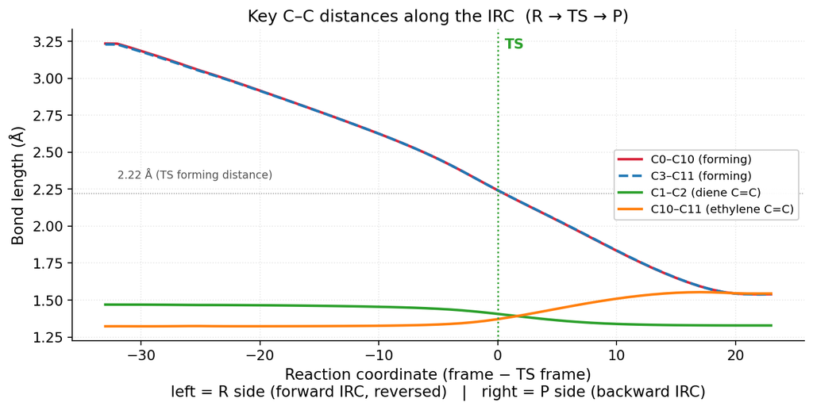

IRC 沿反应坐标的关键键长演化：两根 C–C 形成键（红/蓝虚线）从 R 侧 ~3.25 Å 单调收缩到 P 侧 ~1.54 Å，TS 处恰好 ~2.22 Å；同时丁二烯中心 C1–C2（绿）从单键 1.47 Å → 双键 1.32 Å，乙烯 C10–C11（橙）从双键 1.33 Å → 单键 1.54 Å。**两根形成键全程严格等长，再次证明严格 C2v 同步**

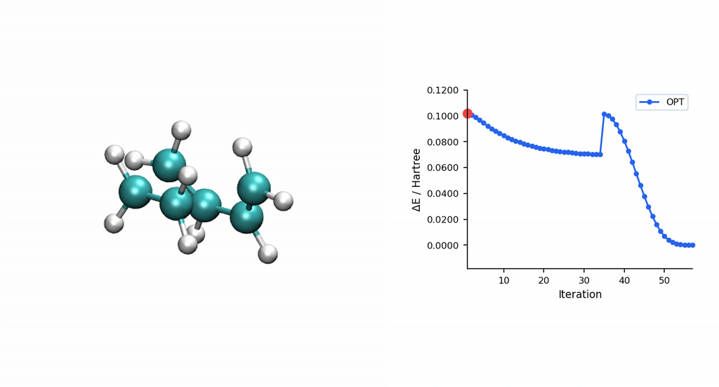

完整 IRC 反应动画（VMD/Tachyon 渲染 CPK 风格 + 同步移动的能量红点；用 MAPLE 自带的 `maple_visual_lab.py` 生成）。可清晰看到两根 C–C 形成键同步收缩、丁二烯/乙烯双键交换的过程

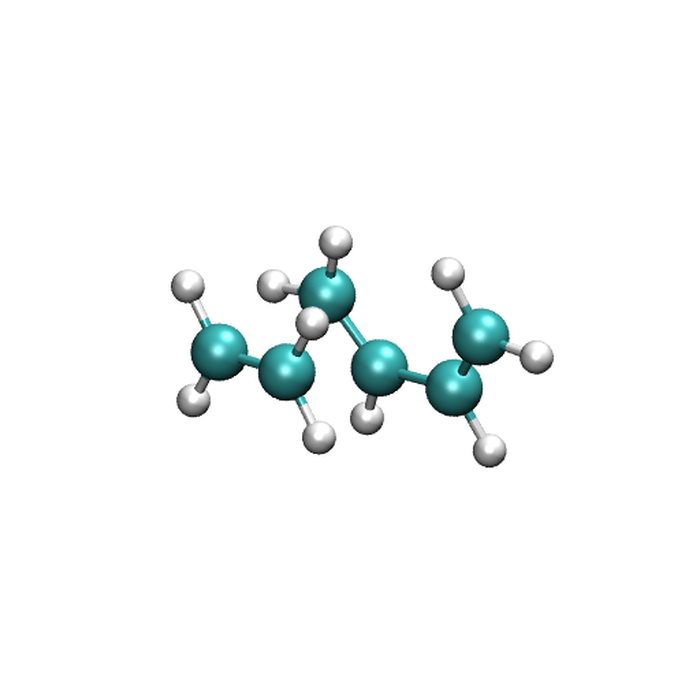

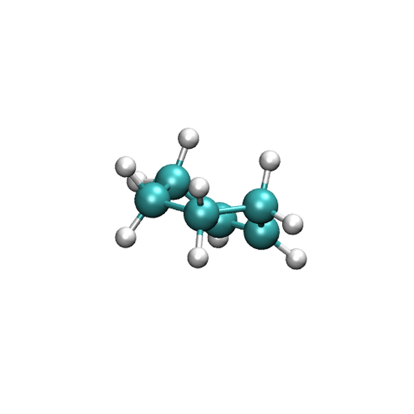

*IRC 双向再 OPT 端点（VMD/Tachyon 渲染）— 左：pre-reactive R 复合物（−234.526 Eh）；右：环己烯产物（−234.596 Eh）。两端能量与 §3.1 独立优化结果严格一致，形成完整的”PRFO + freq + IRC + 端点 OPT”*

**端点结构提取与再优化**：按 Sobereva 老师在博文 400 中的提醒：“IRC 两端的点不会恰好是极小点，需要再做一次几何优化才能严格对应反应物/产物结构”。做法是把 `irc_uma_forward.xyz` 和 `irc_uma_backward.xyz` 的最后一帧取出，再各跑一次 `#opt(method=lbfgs,level=tight)`。实测：

[output not shown]

**IRC 同时严谨地连回了反应物和产物两端**，与 P-RFO 找到的 TS 一致：正反应能垒 19.8 kcal/mol、反应能 −44.2 kcal/mol 由 PRFO + IRC + 端点 OPT 三条独立路径互相交叉验证。这就是“过渡态合理性的完整证据链”。

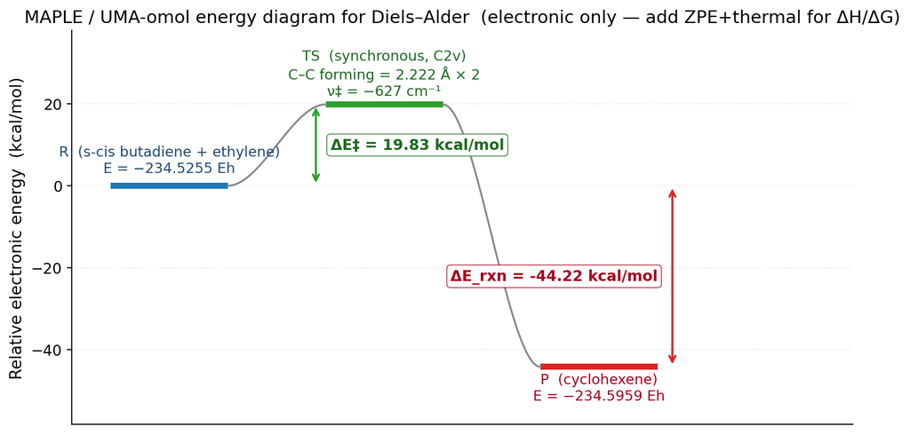

D-A 反应能量图：MAPLE/UMA-omol 给出 ΔE‡ = 19.83 kcal/mol（与文献 CCSD(T)/B3LYP-D3 约 22–25 kcal/mol 吻合），ΔE_rxn = −44.22 kcal/mol（与实验 ΔH(298K) ≈ −40 kcal/mol 吻合，差异源自电子能 vs 焓）

### 3.5 整体耗时复盘

| 步骤 | 实际耗时 | 输出 |
| --- | --- | --- |
| 3.1 反应物预优化 | 16.5 s | R 优化结构、E_R = −234.525473 Eh |
| 3.1 产物预优化 | 13.1 s | P 优化结构、E_P = −234.595945 Eh |
| 3.2 P-RFO 精修 TS | 167.9 s | 同步 TS, ΔE‡ = 19.8 kcal/mol, C—C 形成 2.22 Å × 2 |
| 3.3 频率分析 | 21.6 s | 1 虚频 −627.43 cm⁻¹, 41 实频 |
| 3.4 IRC（双向） | 53.5 s | 57 步全连通，full/forward/backward 三个轨迹文件 |
| 3.4 IRC 端点 OPT（正向） | 10.8 s | pre-reactive R 复合物（−234.526176 Eh） |
| 3.4 IRC 端点 OPT（反向） | 9.6 s | 环己烯（−234.595945 Eh，与 P 严格一致） |
| **完整流程合计** | **293.0 s (~4.9 分钟)** | R → TS → freq → IRC → 端点 OPT |

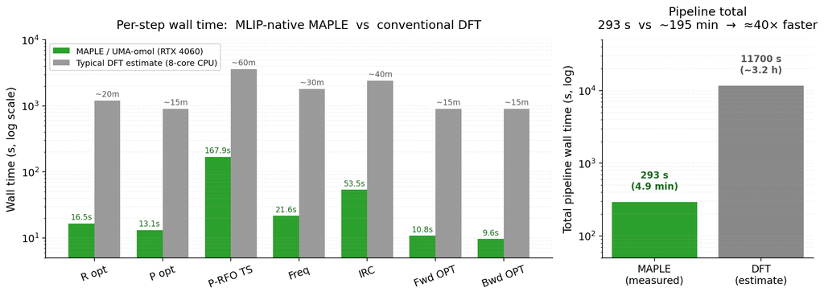

MAPLE 全流程实测耗时（绿）vs 同等规模 DFT 估算（灰）。左图按任务分项，右图整体合计。右图清晰显示：MAPLE 不到 5 分钟、DFT 估算 3 小时左右，**整体加速 ≈ 40×**（注：DFT 数字为 B3LYP-D3BJ/6-31G(d) 8 核 CPU 上的保守估计，实际可能更长）

## 四、性能与精度的”边界条件”——本次实测的几条体会

经过本节的实战，笔者想强调以下几点真实使用 MLIP 时容易遇到的”坑”：

**1. 模型与体系的匹配比模型大小更重要。** 笔者最初尝试用 `maceoff23m`（MACE-OFF23 medium，主要在 SPICE 平衡态数据上训练）跑这个 D-A 反应，反复出现非物理鞍点：形成键 ~2.8 或 ~3.8 Å、虚频 −82 cm⁻¹、或者 P-RFO 直接把同步 TS 初猜推回到分离态。**根本原因是 SPICE 训练集不覆盖键正在形成的 ~2.0–2.5 Å 中间区域**，MACE-OFF 在那一带是外推。换成 `uma(task=omol)`（基于 OMol25 训练，包含大量反应路径）后，一次就给出严格 C2v 同步 TS、−627 cm⁻¹ 虚频、能垒和反应能与 DFT 吻合。**选模型务必先看训练数据是否覆盖你的反应类型**。

**2. NEB 的初猜路径质量决定一切。** 本节没有展示 NEB 是因为 D-A 的 P-RFO 初猜很容易手搓；但对其他反应若用 NEB，第一关卡是 **R 与 P 的原子顺序必须一致**——否则 IDPP 插值会把原子互相穿插，最终 HEI 跑到 +100 kcal/mol 以上的非物理结构。简单做法是在 R 优化完之后用脚本（或 OpenBabel `--orderbysym`）按 R 的顺序重排 P 文件。

**3. 找到鞍点之后必须做频率分析。** P-RFO 给出”收敛”的结构不一定是合理的过渡态——可能是高阶鞍点、错误反应通道，或者数值上的伪鞍点。**只有 freq 报告”1 虚频 + 模式对应反应坐标”才算 TS 验证完毕**。本例中 −627.43 cm⁻¹、对应 C—C 同步伸缩，符合 D-A 协同机理的预期。

**5. 模型对单点能精度有差异，关键能量建议用 DFT 复核。** UMA-omol 在本例中给出 ΔE‡ = 19.8、ΔE_rxn = −44.2，与文献参考相当一致；但对你自己的体系，**最稳的做法仍是 MLIP 找完关键结构后用 DFT/CCSD(T) 在 R、TS、P 三点做单点能精修**，再用精修后的能量算最终的活化能和反应能。MAPLE 的角色是”快速找到正确的几何构型与反应通路”，最终能量交给DFT算。

## 五、适用范围与边界

笔者希望明确指出 MAPLE / MLIP 当前的适用场景，以免读者误用：

**适合（推荐使用）：**

- 主族元素（H, C, N, O, F, Si, P, S, Cl, Br, I 等）的有机分子、有机金属化合物。AIMNet2 直接支持 14 个元素；MACE-OFF 与 UMA 训练于 SPICE/OMol25 等更广数据集，覆盖更宽。
- 构象搜索、几何优化、过渡态搜索、IRC、常规热化学（反应焓、反应自由能、活化能）——前提是模型训练域涵盖目标体系/反应类型。**做反应优先用 UMA-omol、MACE-OMol25、ANI-1xnr 等”含反应数据”的模型**。
- 闭壳层基态计算，以及合理范围内的电荷态（AIMNet2、MACE-OFF、UMA、MACEPol 等支持非中性体系；输入坐标块前写 `0 1` / `-1 1` / `0 2` 等指定电荷与多重度）。
- 单点能精度要求达到中等 DFT 级别即可的应用——UMA-omol 在 GMTKN55 等 benchmark 上通常优于 GFN2-xTB，接近 ωB97X-D/def2-TZVPP 水平。

**边界与注意事项：**

- **反应类型必须落在模型训练域内**。SPICE-only 训练的 MACE-OFF 在 TS 区域容易失效；做反应优先用 OMol25/ANI-1xnr 训练的模型。
- **过渡金属配合物**：UMA 大模型对 d-block 有较好覆盖；其它 MLIP 用前务必先在小体系上验证。
- **电子激发态、单/三重态间隙**：现有通用 MLIP 几乎都只训练基态，做激发态依然要回到 TDDFT/CASSCF。MAPLE 不能取代 ORCA 的 TDDFT。
- **强相关、自由基反应中的开壳层多参考问题**：MLIP 训练数据多基于 DFT 单参考，超出训练分布时可能给出”看似合理但实际错误”的能量。
- **稀有元素**：周期表后排过渡金属、镧系/锕系、超原子价化合物等，MLIP 训练集覆盖有限。

**笔者的实战建议**：

1. **先用 MLIP 做大规模的构象/势能面探索和初步定位关键结构**，再用 DFT 在关键点上做精校单点能。
2. **找到 TS 后必做 freq + IRC**——是验证而不是装饰。本例 IRC 两端误差 < 0.15 kcal/mol，直接交叉验证了 PRFO 找到的鞍点。
3. **如果 MLIP 预测的机理与你 DFT 经验不一致，先用第二个独立模型（如 UMA 和 MACE-OMol25 对比）做交叉验证**，不要轻易接受单一模型的结论。
4. 这种 “MLIP 快速筛选 + DFT 精修”的混合工作流是目前计算化学领域最被认可的策略，最近一两年发表在 *Nat. Comput. Sci.*、*JCTC*、*ChemRxiv* 上的相关文章已经非常多。

## 六、结语

MAPLE 是一个相对较新的项目（v0.1.0 于 2025 年 12 月首发，目前最新版 v0.1.2），但因为底层使用 PyTorch + ASE 这套成熟生态，开发节奏很快，作者也积极接受社区反馈和贡献（期待你们的意见和建议！）。

笔者非常希望我国计算化学界对 MLIP 工具的接受度能持续提升——毕竟我们花在等 DFT 跑完的时间，本来可以用来做更多的化学思考、读更多的文献、想更多的体系。如果读者有兴趣尝试 MAPLE，建议：

1. **先在自己最熟悉的小体系上做一遍**：跑一遍 opt + freq，把 MLIP 给的几何、虚频、键长键角与你之前的 DFT 结果对比一下，建立对 MLIP 精度的直觉。
2. **重点验证关键能量**（如反应能垒、相对自由能），看看 MLIP 给出的值是否在你能接受的误差范围内。本例 ΔE‡ = 19.8、ΔE_rxn = −44.2 kcal/mol，与文献相当吻合，可作为 UMA-omol 在 D-A 类反应上的精度参考。
3. **在生产工作流中采用混合策略**：用 MAPLE 做几何优化、TS 搜索、IRC、构象采样；用 Gaussian / ORCA 在关键单点上做精修。

任何使用问题、bug、改进建议都欢迎到 GitHub Issues（https://github.com/ClickFF/MAPLE/issues ）或者MAPLE交流企鹅群757103155反馈！后续笔者会陆续更新更详细的教程。

敬请期待，也欢迎大家在本帖留言交流使用体验、提建议、报 bug。

**参考文献**

- MAPLE 主页：https://www.maplechem.org/
- MAPLE GitHub：https://github.com/ClickFF/MAPLE
- MAPLE 论文：https://doi.org/10.1039/D6SC01279E
- Sobereva 老师博文《过渡态、反应路径的计算方法及相关问题》：http://sobereva.com/44
- Sobereva 老师博文《在 Gaussian 中计算 IRC 的方法和常见问题》：http://sobereva.com/400
- Sobereva 老师博文《量子化学计算中帮助几何优化收敛的常用方法》：http://sobereva.com/164
- UMA / Open Molecules 2025：FAIR-Chem team, *arXiv* 2025
- ANI-1xnr (reactive ML): Devereux et al., *J. Chem. Theory Comput.*, 2020
- AIMNet2: Anstine, Zubatyuk, Isayev, *Chem. Sci.*, 2025
- MACE / MACE-OFF: Batatia et al., 2022; Kovács et al., 2023